# Analisis Pemulusan (Smoothing) Data Time Series

Suhu Minimum Harian Melbourne - Bagian: Friska Octaviani Zebua

Friska Octaviani Zebua

26 August 2026

## 1. Deskripsi Data

Data yang digunakan adalah **suhu minimum harian (daily minimum temperature)** Kota Melbourne, Australia, yang merupakan dataset kelompok dengan total 3.650 periode (1981-1990). Data dibagi rata ke setiap anggota kelompok; bagian **Friska Octaviani Zebua** adalah observasi ke-**2191** hingga ke-**2920**, yaitu periode **1987-01-01 - 1988-12-30** sebanyak **730 observasi** (memenuhi syarat minimal 100 observasi per orang).

```r
library(ggplot2)
library(reshape2)
library(readxl)

df <- read_excel("data_nomor_2191-2920.xlsx")
df$Date <- as.Date(df$Date)
n <- nrow(df)
y <- ts(df$Temp, frequency = 7)   # frekuensi 7 = pola mingguan

knitr::kable(head(df, 6), caption = "6 observasi pertama data Friska")
```

6 observasi pertama data Friska

| Date | Temp |
| --- | --- |
| 1987-01-01 | 12.3 |
| 1987-01-02 | 13.8 |
| 1987-01-03 | 15.3 |
| 1987-01-04 | 15.6 |
| 1987-01-05 | 16.2 |
| 1987-01-06 | 16.3 |

Ringkasan statistik deskriptif:

```r
summary(df$Temp)
sd(df$Temp)
```

```
##    Min. 1st Qu.  Median    Mean 3rd Qu.    Max.
##   1.50    8.80   11.35   11.41   13.90   24.10
## [1] 3.7280
```

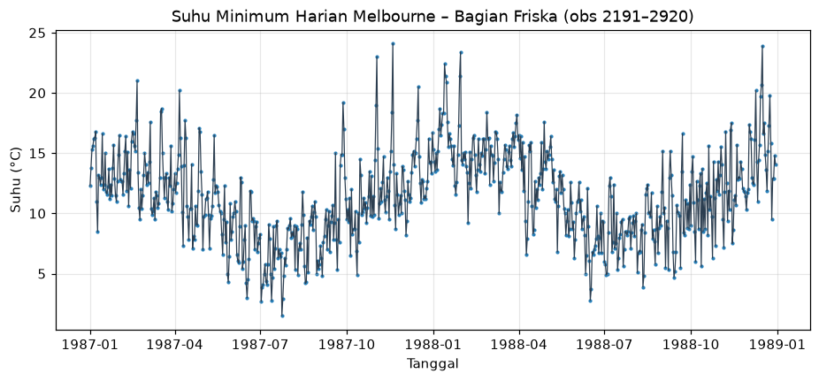

```r
ggplot(df, aes(x = Date, y = Temp)) +
  geom_line(color = "#2c3e50", linewidth = 0.4) +
  geom_point(size = 0.4, color = "#2980b9") +
  labs(title = "Suhu Minimum Harian Melbourne - Bagian Friska",
       subtitle = "Observasi ke-2191 s.d. ke-2920 (730 observasi)",
       x = "Tanggal", y = "Suhu (derajat C)") +
  theme_minimal()
```

Plot menunjukkan adanya **pola musiman tahunan** yang kuat (suhu tinggi pada musim panas Desember-Februari dan rendah pada musim dingin Juni-Agustus) serta fluktuasi harian yang cukup acak, tanpa tren jangka panjang yang jelas.

## 2. Fungsi Metrik Akurasi

Untuk membandingkan kinerja tiap metode digunakan empat metrik: SSE, MSE, RMSE, dan MAPE.

```r
akurasi <- function(actual, fitted) {
  valid <- !is.na(fitted)
  err   <- actual[valid] - fitted[valid]
  data.frame(
    SSE  = sum(err^2),
    MSE  = mean(err^2),
    RMSE = sqrt(mean(err^2)),
    MAPE = mean(abs(err / actual[valid])) * 100,
    n_valid = sum(valid)
  )
}
```

## 3. Metode Pemulusan

### 3.1 Simple Moving Average (SMA)

SMA dengan orde `m = 3`: nilai ramalan periode ke-t adalah rata-rata 3 observasi sebelumnya.

```r
m <- 3
sma_raw    <- as.numeric(stats::filter(y, rep(1/m, m), sides = 1))
sma_fitted <- c(NA, head(sma_raw, -1))
akurasi_sma <- akurasi(as.numeric(y), sma_fitted)
akurasi_sma
```

```
##       SSE      MSE     RMSE     MAPE n_valid
## 1 5985.49 8.2331 2.8693 22.9338     727
```

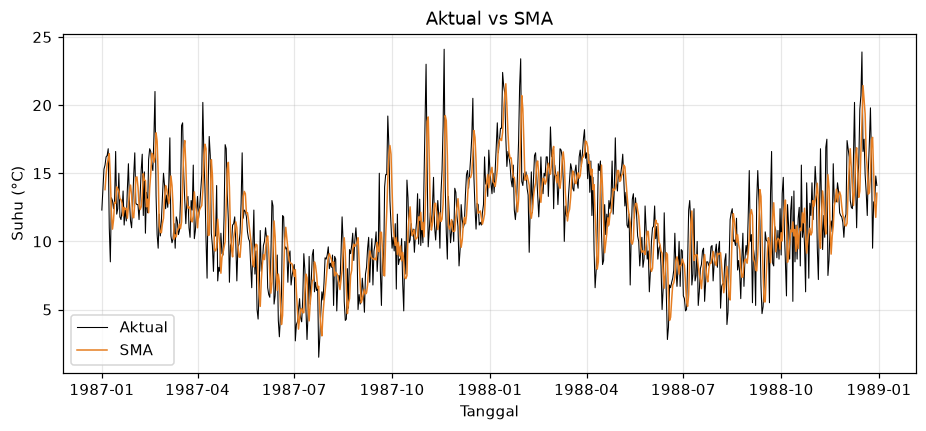

```r
plot_sma <- data.frame(date = df$Date, Aktual = df$Temp, SMA = sma_fitted)
ggplot(melt(plot_sma, id.vars = "date"), aes(date, value, color = variable)) +
  geom_line(linewidth = 0.5) +
  scale_color_manual(values = c(Aktual = "black", SMA = "#e67e22")) +
  labs(title = "Aktual vs SMA (m = 3)", x = "Tanggal", y = "Suhu (derajat C)") +
  theme_minimal()
```

### 3.2 Double Moving Average (DMA)

DMA menambahkan komponen tren melalui rata-rata bergerak kedua.

```r
Mt  <- as.numeric(stats::filter(y, rep(1/m, m), sides = 1))
Mt2 <- as.numeric(stats::filter(Mt, rep(1/m, m), sides = 1))
at  <- 2 * Mt - Mt2
bt  <- (2 / (m - 1)) * (Mt - Mt2)
dma_level  <- at + bt
dma_fitted <- c(NA, head(dma_level, -1))
akurasi_dma <- akurasi(as.numeric(y), dma_fitted)
akurasi_dma
```

```
##       SSE      MSE     RMSE     MAPE n_valid
## 1 9648.42 13.3082 3.6480 28.6923     725
```

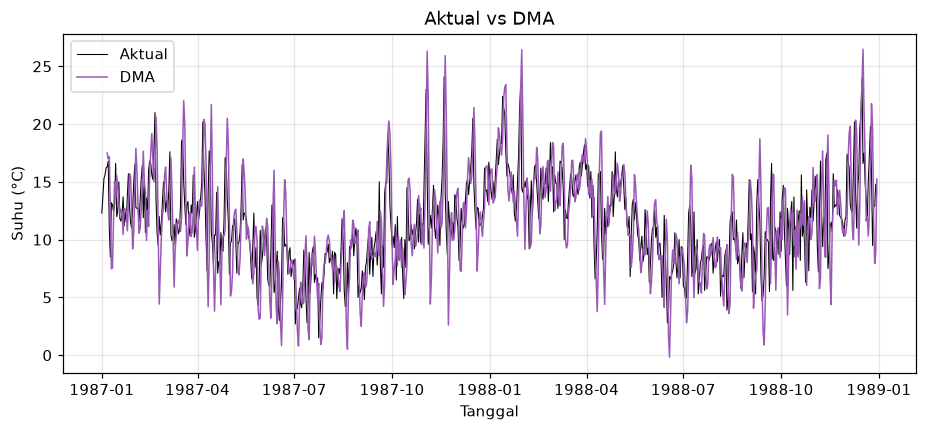

### 3.3 Single Exponential Smoothing (SES)

```r
ses_model  <- HoltWinters(y, beta = FALSE, gamma = FALSE)
ses_fitted <- c(rep(NA, n - nrow(ses_model$fitted)), ses_model$fitted[, 1])
akurasi_ses <- akurasi(as.numeric(y), ses_fitted)
cat("alpha optimum:", round(ses_model$alpha, 4), "\n")
```

```
## alpha optimum: 0.5135
```

```r
akurasi_ses
```

```
##       SSE      MSE     RMSE     MAPE n_valid
## 1 5002.25 6.8618 2.6195 21.0080     729
```

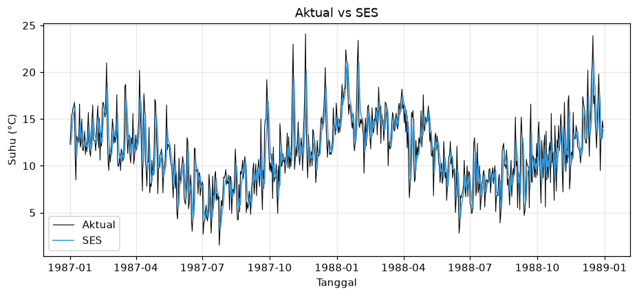

### 3.4 Double Exponential Smoothing / Holt (DES)

```r
des_model  <- HoltWinters(y, gamma = FALSE)
des_fitted <- c(rep(NA, n - nrow(des_model$fitted)), des_model$fitted[, 1])
akurasi_des <- akurasi(as.numeric(y), des_fitted)
cat("alpha optimum:", round(des_model$alpha, 4),
    "| beta optimum:", round(des_model$beta, 4), "\n")
```

```
## alpha optimum: 0.6487 | beta optimum: 0.0240
```

```r
akurasi_des
```

[output not shown]

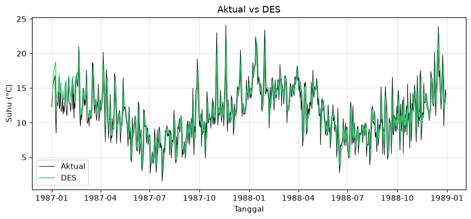

### 3.5 Holt-Winters (Triple Exponential Smoothing)

```r
hw_model  <- HoltWinters(y)   # seasonal = "additive", frequency = 7
hw_fitted <- c(rep(NA, n - nrow(hw_model$fitted)), hw_model$fitted[, 1])
akurasi_hw <- akurasi(as.numeric(y), hw_fitted)
cat("alpha:", round(hw_model$alpha, 4),
    "| beta:", round(hw_model$beta, 4),
    "| gamma:", round(hw_model$gamma, 4), "\n")
```

```
## alpha: 0.5415 | beta: 0.0069 | gamma: 0.1141
```

```r
akurasi_hw
```

```
##       SSE      MSE     RMSE     MAPE n_valid
## 1 5293.47 7.3215 2.7058 21.3684     723
```

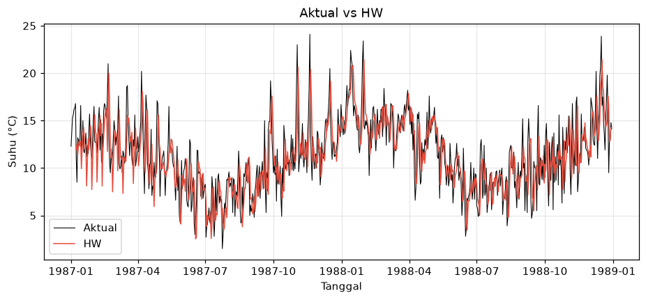

## 4. Perbandingan Kinerja Metode

```r
hasil <- rbind(
  cbind(Metode = "SMA (m=3)", akurasi_sma),
  cbind(Metode = "DMA (m=3)", akurasi_dma),
  cbind(Metode = "SES", akurasi_ses),
  cbind(Metode = "DES (Holt)", akurasi_des),
  cbind(Metode = "Holt-Winters", akurasi_hw)
)
hasil <- hasil[order(hasil$RMSE), ]
knitr::kable(hasil, digits = 2, row.names = FALSE,
             caption = "Perbandingan metrik akurasi tiap metode (diurutkan dari terbaik)")
```

Perbandingan metrik akurasi tiap metode (diurutkan dari terbaik)

| Metode | SSE | MSE | RMSE | MAPE (%) | n_valid |
| --- | --- | --- | --- | --- | --- |
| SES | 5002.25 | 6.86 | 2.62 | 21.01 | 729 |
| DES (Holt) | 5253.59 | 7.21 | 2.68 | 21.36 | 729 |
| Holt-Winters | 5293.47 | 7.32 | 2.71 | 21.37 | 723 |
| SMA (m=3) | 5985.49 | 8.23 | 2.87 | 22.93 | 727 |
| DMA (m=3) | 9648.42 | 13.31 | 3.65 | 28.69 | 725 |

[figure not shown]

```r
ggplot(hasil, aes(x = reorder(Metode, RMSE), y = RMSE, fill = Metode)) +
  geom_col() + geom_text(aes(label = round(RMSE, 3)), vjust = -0.4) +
  labs(title = "Perbandingan RMSE Antar Metode", x = NULL, y = "RMSE") +
  theme_minimal() + theme(legend.position = "none")
```

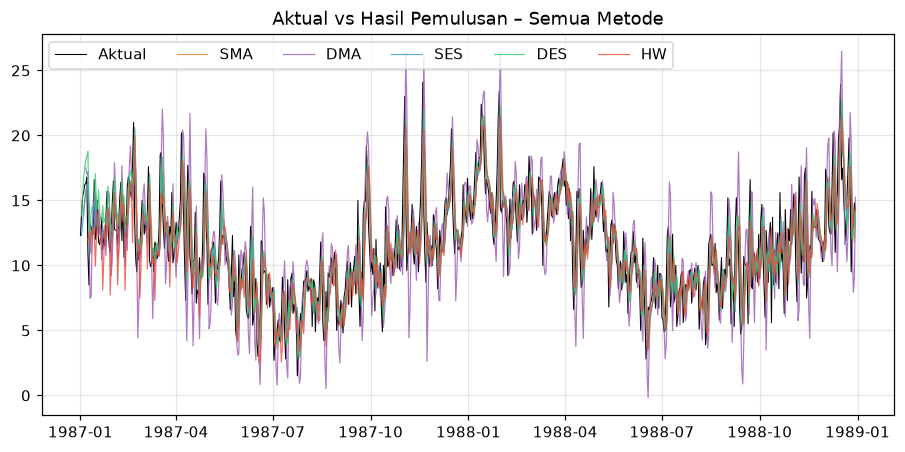

```r
plot_df <- data.frame(
  date = df$Date, Aktual = df$Temp, SMA = sma_fitted, DMA = dma_fitted,
  SES = ses_fitted, DES = des_fitted, HW = hw_fitted
)
plot_long <- melt(plot_df, id.vars = "date")

ggplot(plot_long, aes(x = date, y = value, color = variable)) +
  geom_line(linewidth = 0.5) +
  scale_color_manual(values = c(Aktual = "black", SMA = "#e67e22",
                                DMA = "#9b59b6", SES = "#3498db",
                                DES = "#2ecc71", HW = "#e74c3c")) +
  labs(title = "Aktual vs Hasil Pemulusan - Semua Metode",
       x = "Tanggal", y = "Suhu (derajat C)", color = "Seri") +
  theme_minimal()
```

## 5. Kesimpulan

1. Metode terbaik untuk data suhu minimum harian bagian Friska adalah **SES** dengan RMSE terkecil sebesar **2.6195** (MSE 6.8618; SSE 5002.25; MAPE 21.01%).
2. SES unggul karena data harian ini **tidak memiliki tren jangka panjang** pada rentang dua tahun tersebut dan variasinya sebagian besar acak di sekitar level yang bergerak perlahan, sehingga pembobotan eksponensial pada level saja (alpha = 0.5135) sudah cukup menangkap pola.
3. **DES** dan **Holt-Winters** memberikan akurasi yang hampir sama, namun sedikit lebih buruk karena parameter tren (beta) dan musiman mingguan (gamma) yang diestimasi bernilai kecil - artinya kedua komponen tersebut hanya menambah kompleksitas tanpa perbaikan berarti (pola musiman data ini bersifat tahunan, bukan mingguan).
4. **DMA** menjadi metode terburuk (RMSE 3.6480) karena ekstrapolasi tren dari rata-rata bergerak ganda justru memperbesar noise pada data harian yang fluktuatif.
5. Secara umum, semakin sederhana model pada data yang dominan acak (random walk-like), semakin baik akurasinya - sesuai prinsip parsimony dalam pemodelan deret waktu.